# PredCatch_Analysis_HackathonProj

```r
#Reading Data
Data_PredCat <- read.csv(choose.files())
```

```r
dim(Data_PredCat)
```

1. 227845

2. 28

```r
str(Data_PredCat)
```

```
'data.frame':	227845 obs. of  28 variables:
 $ id            : int  112751 18495 23915 50806 184244 144029 127618 116319 66485 117942 ...
 $ Group         : Factor w/ 1301 levels "Grp0","Grp1",..: 421 414 524 453 487 733 989 453 864 535 ...
 $ Per1          : num  1.07 0.473 1.13 0.637 0.56 ...
 $ Per2          : num  0.58 1.207 0.143 1.09 1.013 ...
 $ Per3          : num  0.48 0.883 0.947 0.75 0.593 ...
 $ Per4          : num  0.767 1.43 0.123 0.94 0.417 ...
 $ Per5          : num  1.233 0.727 0.08 0.743 0.773 ...
 $ Per6          : num  1.993 0.627 0.837 0.347 0.46 ...
 $ Per7          : num  0.34 0.81 0.0567 0.9567 0.8533 ...
 $ Per8          : num  1.01 0.783 0.757 0.633 0.797 ...
 $ Per9          : num  0.863 0.19 0.227 0.487 0.517 ...
 $ Dem1          : num  0.46 0.47 0.66 1.097 0.757 ...
 $ Dem2          : num  0.643 0.613 0.73 0.467 0.683 ...
 $ Dem3          : num  0.737 0.883 0.873 0.67 0.297 ...
 $ Dem4          : num  0.757 0.653 0.923 0.527 0.78 ...
 $ Dem5          : num  0.813 0.463 1.223 0.783 0.637 ...
 $ Dem6          : num  0.693 0.483 0.687 0.857 0.783 ...
 $ Dem7          : num  0.667 0.583 0.607 0.717 0.63 ...
 $ Dem8          : num  0.68 0.717 0.69 0.72 0.603 ...
 $ Dem9          : num  0.727 0.743 0.82 0.9 0.487 ...
 $ Cred1         : num  0.607 0.68 0.6 0.68 0.693 ...
 $ Cred2         : num  1.01 0.69 0.383 0.847 0.527 ...
 $ Cred3         : num  0.933 0.56 0.763 0.423 0.52 ...
 $ Cred4         : num  0.603 0.67 0.67 0.52 0.717 ...
 $ Cred5         : num  0.687 0.553 0.687 0.847 0.707 ...
 $ Cred6         : num  0.673 0.653 0.673 0.76 0.673 ...
 $ Normalised_FNT: num  -246 -248 -233 -250 -248 ...
 $ Target        : int  0 0 0 0 0 0 0 0 0 0 ...
```

Read other dataset available with CSV

```r
#Qset_tats.csv
Ds_PrdCth_Qset <- read.csv(choose.files())
```

```r
#Geo_scores.csv
Ds_PrdCth_GeoScre <- read.csv(choose.files())
```

```r
#instance_scores.csv
Ds_PrdCth_InsScre <- read.csv(choose.files())
```

```r
#Lambda_wts.csv
Ds_PrdCth_LamdaScre <- read.csv(choose.files())
```

```r
dim(Ds_PrdCth_Qset)
```

1. 1424035

2. 2

```r
dim(Ds_PrdCth_GeoScre)
```

1. 1424035

2. 2

```r
dim(Ds_PrdCth_InsScre)
```

1. 1424035

2. 2

```r
dim(Ds_PrdCth_LamdaScre)
```

1. 1400

2. 2

```
Ds_PrdCth_Qset, Ds_PrdCth_GeoScre, Ds_PrdCth_InsScre analysing these DataFrame's we can find Mean for id and Value.
```

```r
Data_PredCat <- merge(x=Data_PredCat,y=Ds_PrdCth_LamdaScre,by='Group',all.x = TRUE)
```

```r
colnames(Data_PredCat)
```

1. 'Group'

2. 'id'

3. 'Per1'

4. 'Per2'

5. 'Per3'

6. 'Per4'

7. 'Per5'

8. 'Per6'

9. 'Per7'

10. 'Per8'

11. 'Per9'

12. 'Dem1'

13. 'Dem2'

14. 'Dem3'

15. 'Dem4'

16. 'Dem5'

17. 'Dem6'

18. 'Dem7'

19. 'Dem8'

20. 'Dem9'

21. 'Cred1'

22. 'Cred2'

23. 'Cred3'

24. 'Cred4'

25. 'Cred5'

26. 'Cred6'

27. 'Normalised_FNT'

28. 'Target'

29. 'lambda_wt'

```r
colnames(Ds_PrdCth_Qset)
```

1. 'id'

2. 'qsets_normalized_tat'

```r
Ds_PrdCth_Avg_Qset <- aggregate(qsets_normalized_tat~id,data=Ds_PrdCth_Qset,FUN=mean)
```

```r
dim(Ds_PrdCth_Avg_Qset)
```

1. 284807

2. 2

```r
Data_PredCat <- merge(x=Data_PredCat,y=Ds_PrdCth_Avg_Qset,by='id',all.x = TRUE)
```

```r
colnames(Data_PredCat)
```

1. 'id'

2. 'Group'

3. 'Per1'

4. 'Per2'

5. 'Per3'

6. 'Per4'

7. 'Per5'

8. 'Per6'

9. 'Per7'

10. 'Per8'

11. 'Per9'

12. 'Dem1'

13. 'Dem2'

14. 'Dem3'

15. 'Dem4'

16. 'Dem5'

17. 'Dem6'

18. 'Dem7'

19. 'Dem8'

20. 'Dem9'

21. 'Cred1'

22. 'Cred2'

23. 'Cred3'

24. 'Cred4'

25. 'Cred5'

26. 'Cred6'

27. 'Normalised_FNT'

28. 'Target'

29. 'lambda_wt'

30. 'qsets_normalized_tat'

```r
colnames(Ds_PrdCth_GeoScre)
```

1. 'id'

2. 'geo_score'

```r
Ds_PrdCth_Avg_GeoScre <- aggregate(geo_score~id,data=Ds_PrdCth_GeoScre,FUN=mean)
```

```r
dim(Ds_PrdCth_Avg_GeoScre)
```

1. 284807

2. 2

```r
Data_PredCat <- merge(x=Data_PredCat,y=Ds_PrdCth_Avg_GeoScre,by='id',all.x = TRUE)
```

```r
colnames(Data_PredCat)
```

1. 'id'

2. 'Group'

3. 'Per1'

4. 'Per2'

5. 'Per3'

6. 'Per4'

7. 'Per5'

8. 'Per6'

9. 'Per7'

10. 'Per8'

11. 'Per9'

12. 'Dem1'

13. 'Dem2'

14. 'Dem3'

15. 'Dem4'

16. 'Dem5'

17. 'Dem6'

18. 'Dem7'

19. 'Dem8'

20. 'Dem9'

21. 'Cred1'

22. 'Cred2'

23. 'Cred3'

24. 'Cred4'

25. 'Cred5'

26. 'Cred6'

27. 'Normalised_FNT'

28. 'Target'

29. 'lambda_wt'

30. 'qsets_normalized_tat'

31. 'geo_score'

```r
colnames(Ds_PrdCth_InsScre)
```

1. 'id'

2. 'instance_scores'

```r
Ds_PrdCth_Avg_InsScre <- aggregate(instance_scores~id,data=Ds_PrdCth_InsScre,FUN=mean)
```

```r
Data_PredCat <- merge(x=Data_PredCat,y=Ds_PrdCth_Avg_InsScre,by='id',all.x = TRUE)
```

```r
colnames(Data_PredCat)
```

1. 'id'

2. 'Group'

3. 'Per1'

4. 'Per2'

5. 'Per3'

6. 'Per4'

7. 'Per5'

8. 'Per6'

9. 'Per7'

10. 'Per8'

11. 'Per9'

12. 'Dem1'

13. 'Dem2'

14. 'Dem3'

15. 'Dem4'

16. 'Dem5'

17. 'Dem6'

18. 'Dem7'

19. 'Dem8'

20. 'Dem9'

21. 'Cred1'

22. 'Cred2'

23. 'Cred3'

24. 'Cred4'

25. 'Cred5'

26. 'Cred6'

27. 'Normalised_FNT'

28. 'Target'

29. 'lambda_wt'

30. 'qsets_normalized_tat'

31. 'geo_score'

32. 'instance_scores'

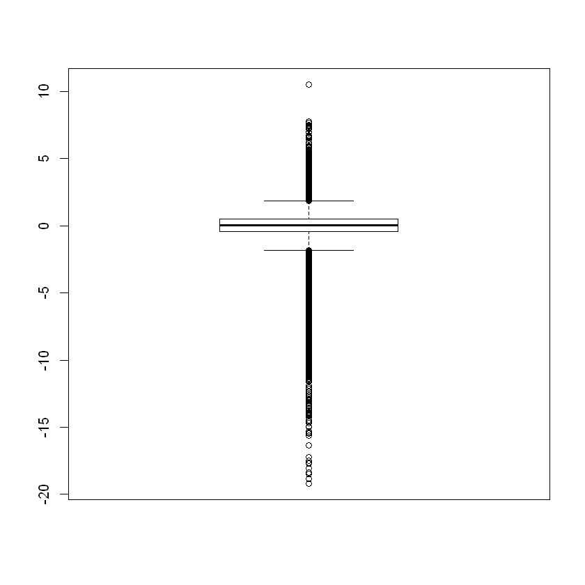

```r
boxplot(Data_PredCat$lambda_wt)
```

```r
Data_PredCat$lambda_wt <- scale(Data_PredCat$lambda_wt)
```

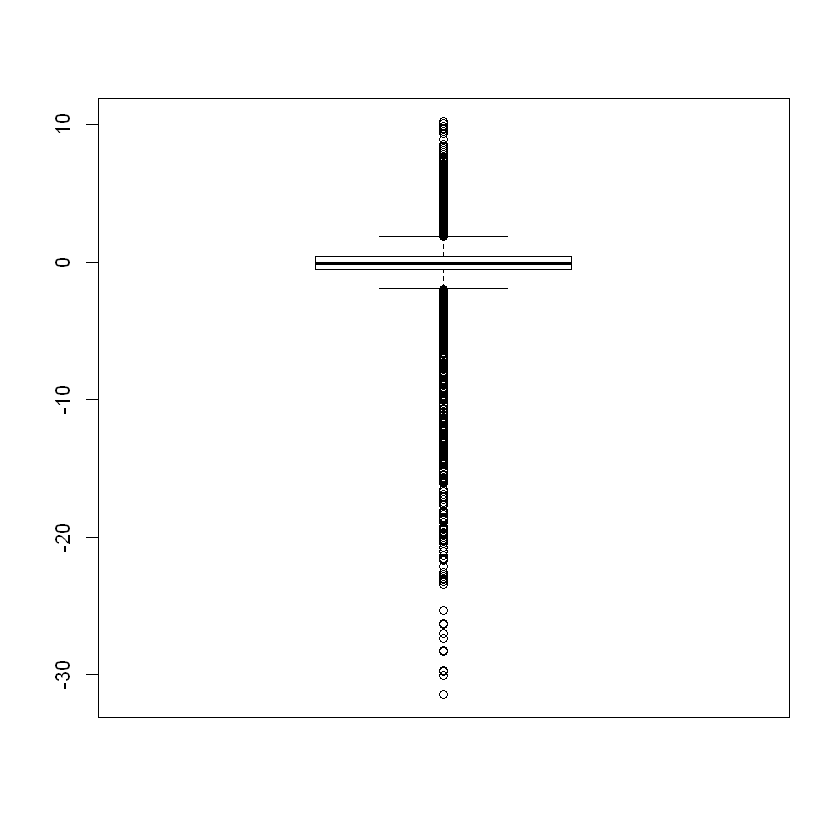

```r
boxplot(Data_PredCat$qsets_normalized_tat)
```

```r
Data_PredCat$qsets_normalized_tat <- scale(Data_PredCat$qsets_normalized_tat)
```

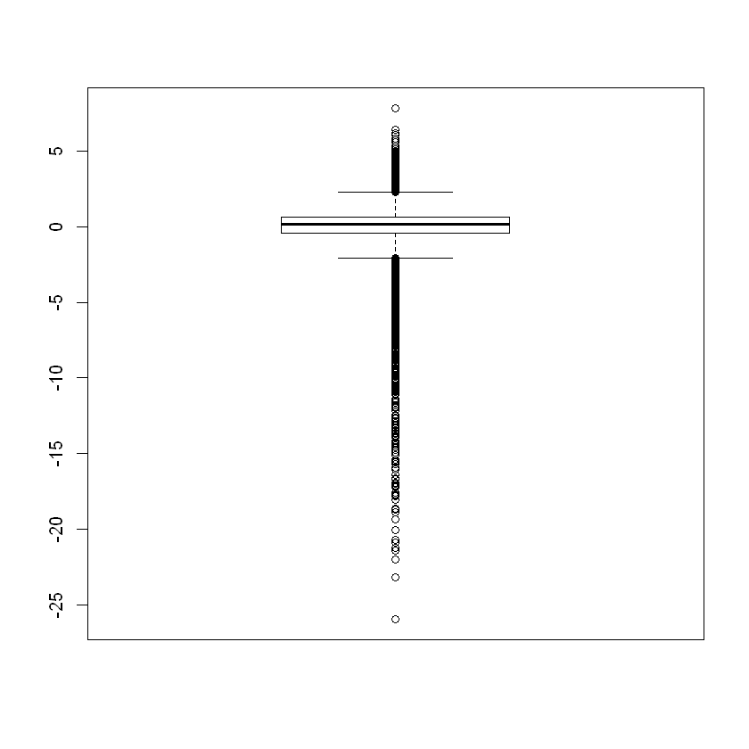

```r
boxplot(Data_PredCat$geo_score)
```

```r
Data_PredCat$geo_score <- scale(Data_PredCat$geo_score)
```

```r
head(Data_PredCat$instance_scores)
```

1. 0.09

2. -0.17

3. 0.21

4. 0.75

5. -0.37

6. -0.1

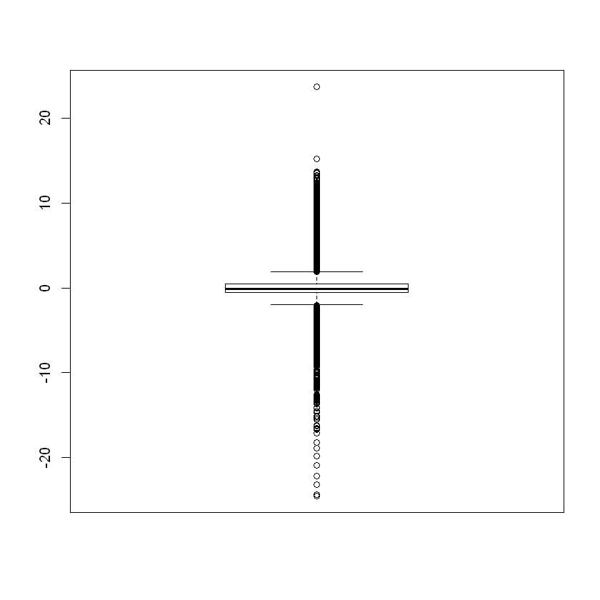

```r
boxplot(Data_PredCat$instance_scores)
```

```r
Data_PredCat$instance_scores <- scale(Data_PredCat$instance_scores)
```

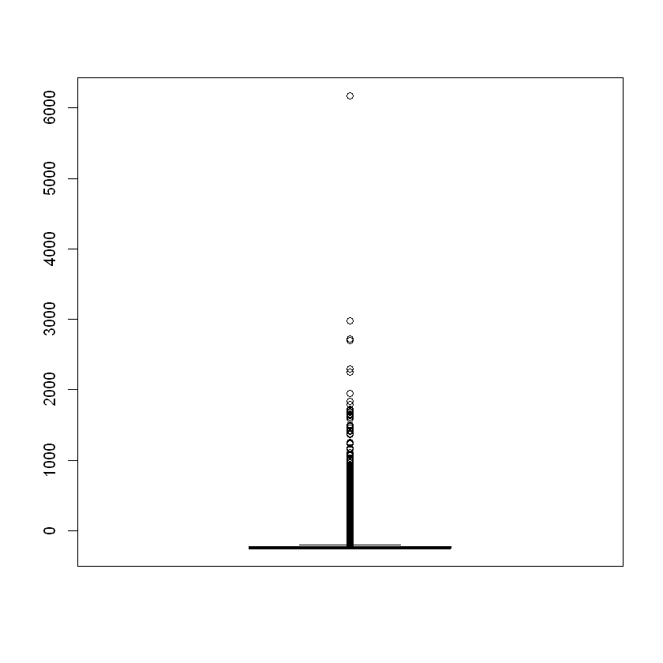

```r
boxplot(Data_PredCat$Normalised_FNT)
```

```r
Data_PredCat$Normalised_FNT <- scale(Data_PredCat$Normalised_FNT)
```

'Per1' 'Per2' 'Per3' 'Per4' 'Per5' 'Per6' 'Per7' 'Per8' 'Per9'- In reduce the number of columns used we take avg of these 9 variales and create a variable named PerAvg.Same as this CredAvg and DemAvg is created combining(Cred1 Cred2 Cred3....Cred6) and (Dem1,....,Dem9)

```r
Data_PredCat$PerAvg <- (Data_PredCat$Per1+Data_PredCat$Per2+Data_PredCat$Per3+Data_PredCat$Per4+Data_PredCat$Per5+Data_PredCat$Per6+Data_PredCat$Per7+Data_PredCat$Per8+Data_PredCat$Per9)/9
```

```r
Data_PredCat$CredAvg <- (Data_PredCat$Cred1+Data_PredCat$Cred2+Data_PredCat$Cred3+Data_PredCat$Cred4+Data_PredCat$Cred5+Data_PredCat$Cred6)/6
```

```r
Data_PredCat$DemAvg <- (Data_PredCat$Dem1+Data_PredCat$Dem2+Data_PredCat$Dem3+Data_PredCat$Dem4+Data_PredCat$Dem5+Data_PredCat$Dem6+Data_PredCat$Dem7+Data_PredCat$Dem8+Data_PredCat$Dem9)/9
```

```r
colnames(Data_PredCat)
```

1. 'id'

2. 'Group'

3. 'Per1'

4. 'Per2'

5. 'Per3'

6. 'Per4'

7. 'Per5'

8. 'Per6'

9. 'Per7'

10. 'Per8'

11. 'Per9'

12. 'Dem1'

13. 'Dem2'

14. 'Dem3'

15. 'Dem4'

16. 'Dem5'

17. 'Dem6'

18. 'Dem7'

19. 'Dem8'

20. 'Dem9'

21. 'Cred1'

22. 'Cred2'

23. 'Cred3'

24. 'Cred4'

25. 'Cred5'

26. 'Cred6'

27. 'Normalised_FNT'

28. 'Target'

29. 'lambda_wt'

30. 'qsets_normalized_tat'

31. 'geo_score'

32. 'instance_scores'

33. 'PerAvg'

34. 'CredAvg'

35. 'DemAvg'

```r
head(Data_PredCat)
```

| id | Group | Per1 | Per2 | Per3 | Per4 | Per5 | Per6 | Per7 | Per8 | ... | Cred6 | Normalised_FNT | Target | lambda_wt | qsets_normalized_tat | geo_score | instance_scores | PerAvg | CredAvg | DemAvg |
| --- | --- | --- | --- | --- | --- | --- | --- | --- | --- | --- | --- | --- | --- | --- | --- | --- | --- | --- | --- | --- |
| 0 | Grp0 | 0.2133333 | 0.6433333 | 1.5133333 | 1.1266667 | 0.5533333 | 0.8200000 | 0.7466667 | 0.7000000 | ... | 0.6600000 | 0.2479218 | 0 | -0.3239704 | 0.277479544 | -0.57575501 | 0.08256896 | 0.7892593 | 0.6672222 | 0.6814815 |
| 1 | Grp1 | 1.0633333 | 0.7566667 | 0.7233333 | 0.8166667 | 0.6866667 | 0.6400000 | 0.6400000 | 0.6966667 | ... | 0.6700000 | -0.3450001 | 0 | -0.1465094 | -0.116449229 | 1.24345509 | -0.15563799 | 0.7337037 | 0.6700000 | 0.7381481 |
| 2 | Grp2 | 0.2133333 | 0.2200000 | 1.2566667 | 0.7933333 | 0.5000000 | 1.2666667 | 0.9300000 | 0.7500000 | ... | 0.6466667 | 1.1721908 | 0 | -0.1778261 | 1.173733597 | 0.06549912 | 0.19251063 | 0.6770370 | 0.6461111 | 0.6651852 |
| 4 | Grp4 | 0.2800000 | 0.9600000 | 1.1833333 | 0.8000000 | 0.5300000 | 0.7000000 | 0.8633333 | 0.5766667 | ... | 0.7400000 | -0.0734174 | 0 | -1.1695199 | -0.253927727 | 0.50229542 | 0.68724815 | 0.7592593 | 0.7072222 | 0.7488889 |
| 5 | Grp1 | 0.5233333 | 0.9866667 | 1.0466667 | 0.6100000 | 0.8066667 | 0.6566667 | 0.8266667 | 0.7533333 | ... | 0.6933333 | -0.3410454 | 0 | -0.1465094 | -0.063572883 | 0.33501173 | -0.33887411 | 0.7429630 | 0.6561111 | 0.7129630 |
| 6 | Grp5 | 1.0766667 | 0.7133333 | 0.6833333 | 1.0666667 | 0.7300000 | 0.7566667 | 0.6633333 | 0.6933333 | ... | 0.6700000 | -0.3357187 | 0 | 0.1770959 | -0.000121269 | -0.17380949 | -0.09150535 | 0.8003704 | 0.6444444 | 0.5229630 |

For Building model we split the Data_PredCat into Training and Test based on Target variable. Split ratio is set to 80%-20% to have more Target=1 scenarios for Building Model.

```r
library(caTools)
```

```r
set.seed(123)
Ds_split1 <- sample.split(Data_PredCat$Target,SplitRatio=0.80)
```

```r
Ds_PrdCth_Train <- subset(Data_PredCat,Ds_split1==TRUE)
```

```r
Ds_PrdCth_Test <- subset(Data_PredCat,Ds_split1==FALSE)
```

```r
colnames(Ds_PrdCth_Train)
```

1. 'id'

2. 'Group'

3. 'Per1'

4. 'Per2'

5. 'Per3'

6. 'Per4'

7. 'Per5'

8. 'Per6'

9. 'Per7'

10. 'Per8'

11. 'Per9'

12. 'Dem1'

13. 'Dem2'

14. 'Dem3'

15. 'Dem4'

16. 'Dem5'

17. 'Dem6'

18. 'Dem7'

19. 'Dem8'

20. 'Dem9'

21. 'Cred1'

22. 'Cred2'

23. 'Cred3'

24. 'Cred4'

25. 'Cred5'

26. 'Cred6'

27. 'Normalised_FNT'

28. 'Target'

29. 'lambda_wt'

30. 'qsets_normalized_tat'

31. 'geo_score'

32. 'instance_scores'

33. 'PerAvg'

34. 'CredAvg'

35. 'DemAvg'

```r
Depnd_Vars <- c('Normalised_FNT','lambda_wt','qsets_normalized_tat','geo_score','instance_scores','PerAvg','CredAvg','DemAvg')
```

```r
DsPrdCth_glm <- glm(as.formula(paste('Target',paste(Depnd_Vars,collapse='+'),sep='~')),data=Ds_PrdCth_Train,family='binomial')
```

```r
summary(DsPrdCth_glm)
```

```
Call:
glm(formula = as.formula(paste("Target", paste(Depnd_Vars, collapse = "+"),
    sep = "~")), family = "binomial", data = Ds_PrdCth_Train)

Deviance Residuals:
    Min       1Q   Median       3Q      Max
-4.8256  -0.0323  -0.0256  -0.0211   4.4759

Coefficients:
                     Estimate Std. Error z value Pr(>|z|)
(Intercept)          -8.20375    0.88179  -9.303  < 2e-16 ***
Normalised_FNT       -0.02150    0.02471  -0.870   0.3842
lambda_wt            -0.79698    0.05069 -15.722  < 2e-16 ***
qsets_normalized_tat -0.07031    0.03750  -1.875   0.0608 .
geo_score            -0.19512    0.07937  -2.458   0.0140 *
instance_scores      -0.44638    0.07171  -6.225 4.83e-10 ***
PerAvg                0.49349    0.33578   1.470   0.1416
CredAvg              -0.77374    0.98073  -0.789   0.4301
DemAvg                0.69205    0.90792   0.762   0.4459
---
Signif. codes:  0 '***' 0.001 '**' 0.01 '*' 0.05 '.' 0.1 ' ' 1

(Dispersion parameter for binomial family taken to be 1)

    Null deviance: 4636.7  on 182275  degrees of freedom
Residual deviance: 1714.9  on 182267  degrees of freedom
AIC: 1732.9

Number of Fisher Scoring iterations: 10
```

```r
Ds_PrdCrd_GlmPredict <- predict(DsPrdCth_glm,newdata=Ds_PrdCth_Test,type='response')
```

```r
Ds_PrdCth_Test_Cbind <- cbind(Ds_PrdCth_Test,Ds_PrdCrd_GlmPredict)
```

```r
Ds_PrdCth_Test_Cbind$PrdVal1 <- ifelse(Ds_PrdCth_Test_Cbind$Ds_PrdCrd_GlmPredict>0.50,1,0)
```

```r
library(caret)
```

```r
library(e1071)
```

```r
cm_Glm <- table(Ds_PrdCth_Test_Cbind$Target,Ds_PrdCth_Test_Cbind$PrdVal1)
```

```r
cm_Glm
```

```
        0     1
  0 45487     3
  1    34    45
```

```r
confusionMatrix(cm_Glm)
```

```
Confusion Matrix and Statistics


        0     1
  0 45487     3
  1    34    45

               Accuracy : 0.9992
                 95% CI : (0.9989, 0.9994)
    No Information Rate : 0.9989
    P-Value [Acc > NIR] : 0.0603

                  Kappa : 0.7083

 Mcnemar's Test P-Value : 8.14e-07

            Sensitivity : 0.9993
            Specificity : 0.9375
         Pos Pred Value : 0.9999
         Neg Pred Value : 0.5696
             Prevalence : 0.9989
         Detection Rate : 0.9982
   Detection Prevalence : 0.9983
      Balanced Accuracy : 0.9684

       'Positive' Class : 0
```

Since expected kappa value is 80% we build decision tree model and check Kappa value.

```r
library(rpart)
```

```r
DsPrdCth_DecsTree <- rpart(as.formula(paste('Target',paste(Depnd_Vars,collapse='+'),sep='~')),data=Ds_PrdCth_Train)
```

```r
summary(DsPrdCth_DecsTree)
```

```
Call:
rpart(formula = as.formula(paste("Target", paste(Depnd_Vars,
    collapse = "+"), sep = "~")), data = Ds_PrdCth_Train)
  n= 182276

          CP nsplit rel error    xerror       xstd
1 0.50315435      0 1.0000000 1.0000168 0.05619835
2 0.07157193      1 0.4968457 0.5098259 0.03682753
3 0.02958072      2 0.4252737 0.4422037 0.03364626
4 0.02161899      3 0.3956930 0.4230443 0.03385508
5 0.01837850      5 0.3524550 0.3969084 0.03179522
6 0.01204038      9 0.2789410 0.3883764 0.03196738
7 0.01000000     10 0.2669006 0.3538035 0.03134084

Variable importance
qsets_normalized_tat            geo_score            lambda_wt
                  34                   20                   19
     instance_scores       Normalised_FNT               PerAvg
                  19                    3                    3
             CredAvg               DemAvg
                   2                    1

Node number 1: 182276 observations,    complexity param=0.5031543
  mean=0.001728149, MSE=0.001725162
  left son=2 (182006 obs) right son=3 (270 obs)
  Primary splits:
      qsets_normalized_tat < -3.860094   to the right, improve=0.50615820, (0 missing)
      geo_score            < -5.126104   to the right, improve=0.40945600, (0 missing)
      lambda_wt            < -6.201061   to the right, improve=0.39758400, (0 missing)
      instance_scores      < -3.56383    to the right, improve=0.36046330, (0 missing)
      PerAvg               < -0.7212963  to the right, improve=0.04211232, (0 missing)
  Surrogate splits:
      geo_score       < -6.017122   to the right, agree=0.999, adj=0.530, (0 split)
      instance_scores < -5.116756   to the right, agree=0.999, adj=0.452, (0 split)
      lambda_wt       < -6.801297   to the right, agree=0.999, adj=0.344, (0 split)
      PerAvg          < -2.798704   to the right, agree=0.999, adj=0.019, (0 split)
      DemAvg          < -0.08185185 to the right, agree=0.999, adj=0.007, (0 split)

Node number 2: 182006 observations,    complexity param=0.07157193
  mean=0.000593387, MSE=0.0005930349
```

[output cut: 141 more lines]

```
      DemAvg          < 0.622963    to the left,  improve=0.2380952, (0 missing)
      PerAvg          < 0.2872222   to the left,  improve=0.1982571, (0 missing)
      lambda_wt       < -14.79226   to the right, improve=0.1794872, (0 missing)
  Surrogate splits:
      PerAvg  < -0.3498148  to the left,  agree=0.750, adj=0.238, (0 split)
      CredAvg < 0.7347222   to the left,  agree=0.719, adj=0.143, (0 split)

Node number 61: 35 observations
  mean=0.9428571, MSE=0.05387755

Node number 120: 21 observations
  mean=0, MSE=0

Node number 121: 43 observations
  mean=0.8372093, MSE=0.1362899
```

```r
Ds_PrdCrd_DesTreePredict <- predict(DsPrdCth_DecsTree,newdata=Ds_PrdCth_Test)
```

```r
Ds_PrdCth_Test_Cbind <- cbind(Ds_PrdCth_Test,Ds_PrdCrd_DesTreePredict)
```

```r
Ds_PrdCth_Test_Cbind$DesTree_PredVal <- ifelse(Ds_PrdCth_Test_Cbind$Ds_PrdCrd_DesTreePredict>0.5,1,0)
```

```r
Cm_DesTree <- table(Ds_PrdCth_Test_Cbind$Target,Ds_PrdCth_Test_Cbind$DesTree_PredVal)
```

```r
Cm_DesTree
```

```
        0     1
  0 45485     5
  1    23    56
```

```r
confusionMatrix(Cm_DesTree)
```

```
Confusion Matrix and Statistics


        0     1
  0 45485     5
  1    23    56

               Accuracy : 0.9994
                 95% CI : (0.9991, 0.9996)
    No Information Rate : 0.9987
    P-Value [Acc > NIR] : 1.839e-06

                  Kappa : 0.7997

 Mcnemar's Test P-Value : 0.001315

            Sensitivity : 0.9995
            Specificity : 0.9180
         Pos Pred Value : 0.9999
         Neg Pred Value : 0.7089
             Prevalence : 0.9987
         Detection Rate : 0.9982
   Detection Prevalence : 0.9983
      Balanced Accuracy : 0.9588

       'Positive' Class : 0
```

We got 79% of kappa score using Decision tree, so to improve further we build model using random forest(more trees).

```r
#Random Forest
library(randomForest)
```

```r
DsPrdCth_RandFrst <- randomForest(as.formula(paste('Target',paste(Depnd_Vars,collapse='+'),sep='~')),data=Ds_PrdCth_Train,ntree=50)
```

```r
summary(DsPrdCth_RandFrst)
```

```
                Length Class  Mode
call                 4 -none- call
type                 1 -none- character
predicted       182276 -none- numeric
mse                 50 -none- numeric
rsq                 50 -none- numeric
oob.times       182276 -none- numeric
importance           8 -none- numeric
importanceSD         0 -none- NULL
localImportance      0 -none- NULL
proximity            0 -none- NULL
ntree                1 -none- numeric
mtry                 1 -none- numeric
forest              11 -none- list
coefs                0 -none- NULL
y               182276 -none- numeric
test                 0 -none- NULL
inbag                0 -none- NULL
terms                3 terms  call
```

```r
Ds_PrdCrd_RandFrstPred <- predict(DsPrdCth_RandFrst,newdata=Ds_PrdCth_Test)
```

```r
Ds_PrdCth_Test_Cbind <- cbind(Ds_PrdCth_Test_Cbind,Ds_PrdCrd_RandFrstPred)
```

```r
Ds_PrdCth_Test_Cbind$Rand_FrstVal <- ifelse(Ds_PrdCth_Test_Cbind$Ds_PrdCrd_RandFrstPred>0.5,1,0)
```

```r
Cm_RandFrst <- table(Ds_PrdCth_Test_Cbind$Target,Ds_PrdCth_Test_Cbind$Rand_FrstVal)
```

```r
confusionMatrix(Cm_RandFrst)
```

```
Confusion Matrix and Statistics


        0     1
  0 45486     4
  1    22    57

               Accuracy : 0.9994
                 95% CI : (0.9992, 0.9996)
    No Information Rate : 0.9987
    P-Value [Acc > NIR] : 3.531e-07

                  Kappa : 0.814

 Mcnemar's Test P-Value : 0.0008561

            Sensitivity : 0.9995
            Specificity : 0.9344
         Pos Pred Value : 0.9999
         Neg Pred Value : 0.7215
             Prevalence : 0.9987
         Detection Rate : 0.9982
   Detection Prevalence : 0.9983
      Balanced Accuracy : 0.9670

       'Positive' Class : 0
```

Kappa score is 81% for the Random Forest build with 50 trees.

Now we predict the testShare.csv with the randomforest model built.

```r
PredCat_TestShr <- read.csv(choose.files())
```

```r
PredCat_TestShr <- merge(x=PredCat_TestShr,y=Ds_PrdCth_LamdaScre,by='Group',all.x = TRUE)
```

```r
PredCat_TestShr <- merge(x=PredCat_TestShr,y=Ds_PrdCth_Avg_Qset,by='id',all.x = TRUE)
```

```r
PredCat_TestShr <- merge(x=PredCat_TestShr,y=Ds_PrdCth_Avg_GeoScre,by='id',all.x = TRUE)
```

```r
PredCat_TestShr <- merge(x=PredCat_TestShr,y=Ds_PrdCth_Avg_InsScre,by='id',all.x = TRUE)
```

```r
head(PredCat_TestShr)
```

| id | Group | Per1 | Per2 | Per3 | Per4 | Per5 | Per6 | Per7 | Per8 | ... | Cred2 | Cred3 | Cred4 | Cred5 | Cred6 | Normalised_FNT | lambda_wt | qsets_normalized_tat | geo_score | instance_scores |
| --- | --- | --- | --- | --- | --- | --- | --- | --- | --- | --- | --- | --- | --- | --- | --- | --- | --- | --- | --- | --- |
| 3 | Grp3 | 0.3433333 | 0.6033333 | 1.2633333 | 0.3800000 | 0.6633333 | 1.0833333 | 0.7466667 | 0.7933333 | ... | 0.2733333 | 0.8833333 | 0.5933333 | 0.6866667 | 0.6866667 | -219.1250 | -0.29 | -0.850 | 0.1800 | -0.05 |
| 7 | Grp6 | 0.4533333 | 1.1400000 | 1.0233333 | 0.5033333 | 0.9833333 | 0.8100000 | 1.0400000 | -0.6033333 | ... | 0.4500000 | 0.5266667 | 0.6500000 | 0.2633333 | 0.3033333 | -239.8000 | -1.32 | -1.525 | 0.2900 | 1.25 |
| 12 | Grp11 | 1.0833333 | 0.2600000 | 0.7933333 | 0.2566667 | 0.1700000 | 0.4166667 | 0.4366667 | 0.5900000 | ... | 0.7966667 | 0.7200000 | 0.5500000 | 0.6766667 | 0.6800000 | -219.6250 | -0.32 | 0.870 | -0.2400 | 1.32 |
| 13 | Grp12 | 1.0233333 | 0.7633333 | 0.9433333 | 1.5700000 | 0.6066667 | 0.7800000 | 0.6333333 | 0.7066667 | ... | 0.7000000 | 0.8500000 | 0.7000000 | 0.6733333 | 0.6733333 | -243.1250 | -0.18 | 0.120 | 0.3200 | 0.46 |
| 18 | Grp16 | -1.1333333 | -1.1500000 | 1.0633333 | 1.2466667 | 1.6833333 | 0.0800000 | 0.1466667 | 0.7200000 | ... | 0.6800000 | 0.5066667 | 0.4600000 | 0.7966667 | 0.9833333 | -238.3000 | -0.48 | -0.730 | 1.2125 | 0.35 |
| 20 | Grp18 | 0.8966667 | 0.2133333 | 1.0100000 | 0.9433333 | 0.2700000 | 1.1033333 | 0.3733333 | 0.8166667 | ... | 0.5666667 | 0.6900000 | 0.5266667 | 0.6966667 | 0.6866667 | -192.0725 | -0.37 | 0.650 | 1.3000 | 0.57 |

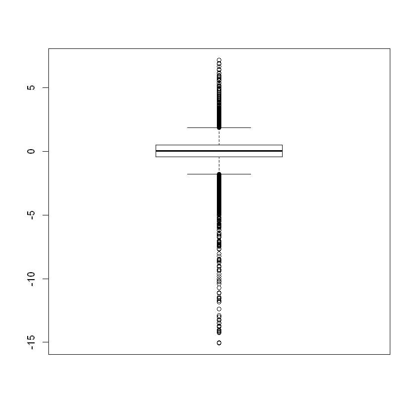

```r
boxplot(PredCat_TestShr$lambda_wt)
```

```r
PredCat_TestShr$lambda_wt <- scale(PredCat_TestShr$lambda_wt)
```

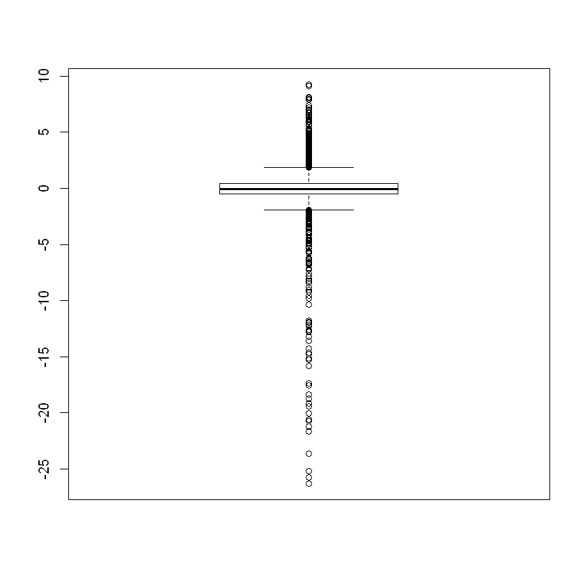

```r
boxplot(PredCat_TestShr$qsets_normalized_tat)
```

```r
PredCat_TestShr$qsets_normalized_tat <- scale(PredCat_TestShr$qsets_normalized_tat)
```

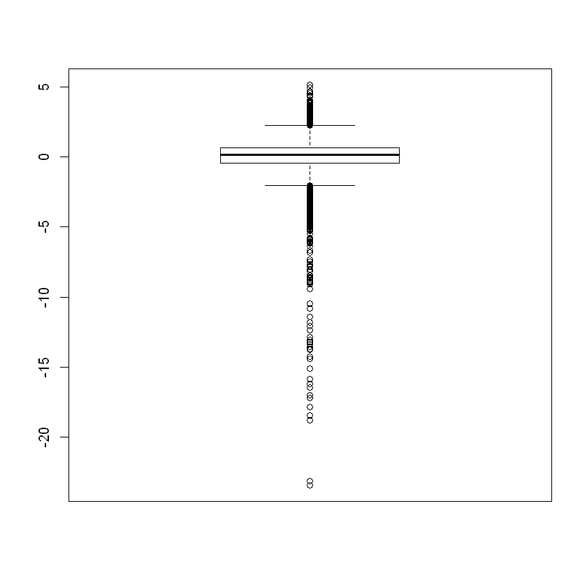

```r
boxplot(PredCat_TestShr$geo_score)
```

```r
PredCat_TestShr$geo_score <- scale(PredCat_TestShr$geo_score)
```

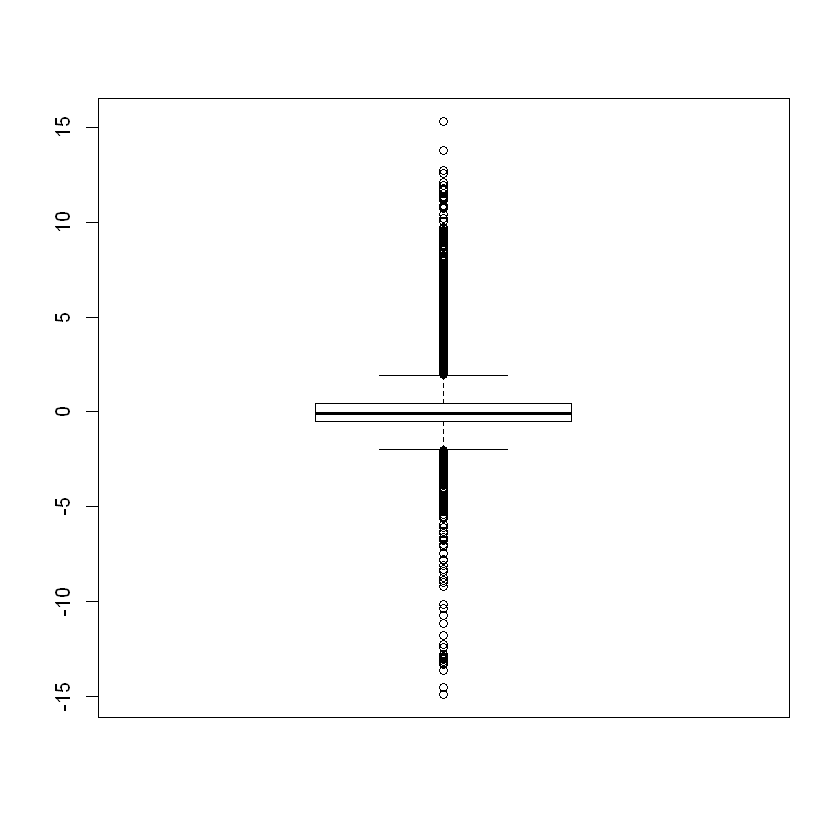

```r
boxplot(PredCat_TestShr$instance_scores)
```

```r
PredCat_TestShr$instance_scores <- scale(PredCat_TestShr$instance_scores)
```

```r
head(PredCat_TestShr)
```

| id | Group | Per1 | Per2 | Per3 | Per4 | Per5 | Per6 | Per7 | Per8 | ... | Cred2 | Cred3 | Cred4 | Cred5 | Cred6 | Normalised_FNT | lambda_wt | qsets_normalized_tat | geo_score | instance_scores |
| --- | --- | --- | --- | --- | --- | --- | --- | --- | --- | --- | --- | --- | --- | --- | --- | --- | --- | --- | --- | --- |
| 3 | Grp3 | 0.3433333 | 0.6033333 | 1.2633333 | 0.3800000 | 0.6633333 | 1.0833333 | 0.7466667 | 0.7933333 | ... | 0.2733333 | 0.8833333 | 0.5933333 | 0.6866667 | 0.6866667 | -219.1250 | -0.3002714 | -0.9064427 | 0.1654737 | -0.04681447 |
| 7 | Grp6 | 0.4533333 | 1.1400000 | 1.0233333 | 0.5033333 | 0.9833333 | 0.8100000 | 1.0400000 | -0.6033333 | ... | 0.4500000 | 0.5266667 | 0.6500000 | 0.2633333 | 0.3033333 | -239.8000 | -1.3718450 | -1.6249326 | 0.2669546 | 1.15884329 |
| 12 | Grp11 | 1.0833333 | 0.2600000 | 0.7933333 | 0.2566667 | 0.1700000 | 0.4166667 | 0.4366667 | 0.5900000 | ... | 0.7966667 | 0.7200000 | 0.5500000 | 0.6766667 | 0.6800000 | -219.6250 | -0.3314823 | 0.9243760 | -0.2219987 | 1.22376333 |
| 13 | Grp12 | 1.0233333 | 0.7633333 | 0.9433333 | 1.5700000 | 0.6066667 | 0.7800000 | 0.6333333 | 0.7066667 | ... | 0.7000000 | 0.8500000 | 0.7000000 | 0.6733333 | 0.6733333 | -243.1250 | -0.1858315 | 0.1260539 | 0.2946312 | 0.42617434 |
| 18 | Grp16 | -1.1333333 | -1.1500000 | 1.0633333 | 1.2466667 | 1.6833333 | 0.0800000 | 0.1466667 | 0.7200000 | ... | 0.6800000 | 0.5066667 | 0.4600000 | 0.7966667 | 0.9833333 | -238.3000 | -0.4979404 | -0.7787111 | 1.1180101 | 0.32415715 |
| 20 | Grp18 | 0.8966667 | 0.2133333 | 1.0100000 | 0.9433333 | 0.2700000 | 1.1033333 | 0.3733333 | 0.8166667 | ... | 0.5666667 | 0.6900000 | 0.5266667 | 0.6966667 | 0.6866667 | -192.0725 | -0.3835005 | 0.6902015 | 1.1987335 | 0.52819154 |

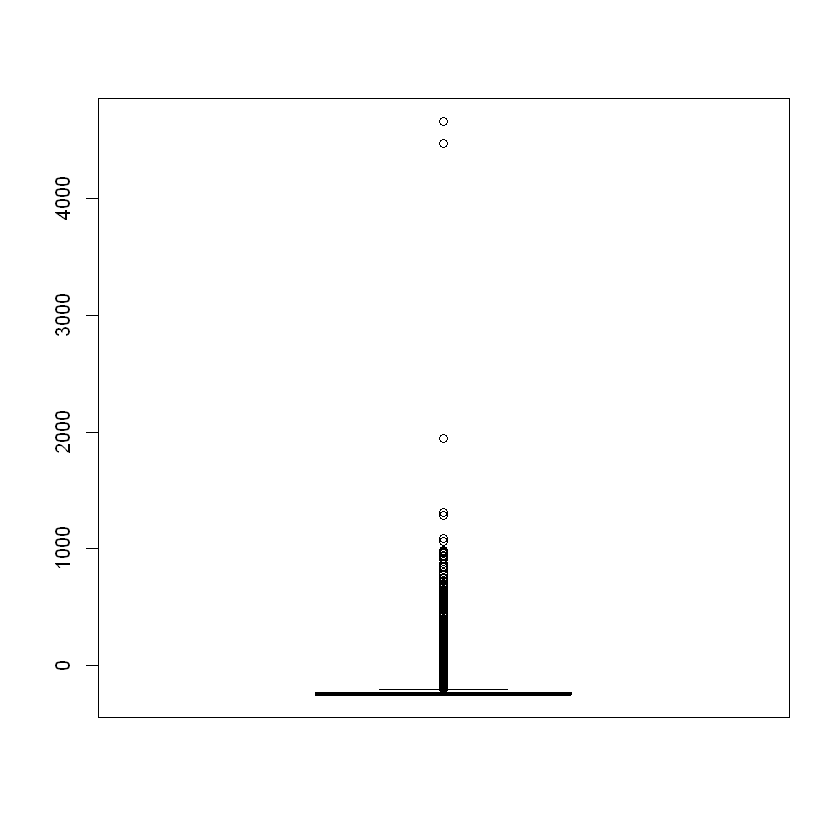

```r
boxplot(PredCat_TestShr$Normalised_FNT)
```

```r
PredCat_TestShr$Normalised_FNT <- scale(PredCat_TestShr$Normalised_FNT)
```

```r
PredCat_TestShr$PerAvg <- (PredCat_TestShr$Per1+PredCat_TestShr$Per2+PredCat_TestShr$Per3+PredCat_TestShr$Per4+PredCat_TestShr$Per5+PredCat_TestShr$Per6+PredCat_TestShr$Per7+PredCat_TestShr$Per8+PredCat_TestShr$Per9)/9
```

```r
PredCat_TestShr$CredAvg <- (PredCat_TestShr$Cred1+PredCat_TestShr$Cred2+PredCat_TestShr$Cred3+PredCat_TestShr$Cred4+PredCat_TestShr$Cred5+PredCat_TestShr$Cred6)/6
```

```r
PredCat_TestShr$DemAvg <- (PredCat_TestShr$Dem1+PredCat_TestShr$Dem2+PredCat_TestShr$Dem3+PredCat_TestShr$Dem4+PredCat_TestShr$Dem5+PredCat_TestShr$Dem6+PredCat_TestShr$Dem7+PredCat_TestShr$Dem8+PredCat_TestShr$Dem9)/9
```

```r
colnames(PredCat_TestShr)
```

1. 'id'

2. 'Group'

3. 'Per1'

4. 'Per2'

5. 'Per3'

6. 'Per4'

7. 'Per5'

8. 'Per6'

9. 'Per7'

10. 'Per8'

11. 'Per9'

12. 'Dem1'

13. 'Dem2'

14. 'Dem3'

15. 'Dem4'

16. 'Dem5'

17. 'Dem6'

18. 'Dem7'

19. 'Dem8'

20. 'Dem9'

21. 'Cred1'

22. 'Cred2'

23. 'Cred3'

24. 'Cred4'

25. 'Cred5'

26. 'Cred6'

27. 'Normalised_FNT'

28. 'lambda_wt'

29. 'qsets_normalized_tat'

30. 'geo_score'

31. 'instance_scores'

32. 'PerAvg'

33. 'CredAvg'

34. 'DemAvg'

```r
PredCat_TestShr_RandFrstPred <- predict(DsPrdCth_RandFrst,newdata=PredCat_TestShr)
```

```r
PredCat_TestShr_Cbind <- cbind(PredCat_TestShr,PredCat_TestShr_RandFrstPred)
```

```r
head(PredCat_TestShr_Cbind)
```

| id | Group | Per1 | Per2 | Per3 | Per4 | Per5 | Per6 | Per7 | Per8 | ... | Cred6 | Normalised_FNT | lambda_wt | qsets_normalized_tat | geo_score | instance_scores | PerAvg | CredAvg | DemAvg | PredCat_TestShr_RandFrstPred |
| --- | --- | --- | --- | --- | --- | --- | --- | --- | --- | --- | --- | --- | --- | --- | --- | --- | --- | --- | --- | --- |
| 3 | Grp3 | 0.3433333 | 0.6033333 | 1.2633333 | 0.3800000 | 0.6633333 | 1.0833333 | 0.7466667 | 0.7933333 | ... | 0.6866667 | 0.1330609 | -0.3002714 | -0.9064427 | 0.1654737 | -0.04681447 | 0.6755556 | 0.6211111 | 0.6303704 | -8.177270e-16 |
| 7 | Grp6 | 0.4533333 | 1.1400000 | 1.0233333 | 0.5033333 | 0.9833333 | 0.8100000 | 1.0400000 | -0.6033333 | ... | 0.3033333 | -0.1860365 | -1.3718450 | -1.6249326 | 0.2669546 | 1.15884329 | 0.6914815 | 0.4800000 | 0.7581481 | -2.117707e-16 |
| 12 | Grp11 | 1.0833333 | 0.2600000 | 0.7933333 | 0.2566667 | 0.1700000 | 0.4166667 | 0.4366667 | 0.5900000 | ... | 0.6800000 | 0.1253439 | -0.3314823 | 0.9243760 | -0.2219987 | 1.22376333 | 0.4418519 | 0.6861111 | 0.6300000 | -4.754140e-16 |
| 13 | Grp12 | 1.0233333 | 0.7633333 | 0.9433333 | 1.5700000 | 0.6066667 | 0.7800000 | 0.6333333 | 0.7066667 | ... | 0.6733333 | -0.2373544 | -0.1858315 | 0.1260539 | 0.2946312 | 0.42617434 | 0.8466667 | 0.7066667 | 0.5288889 | -5.419493e-16 |
| 18 | Grp16 | -1.1333333 | -1.1500000 | 1.0633333 | 1.2466667 | 1.6833333 | 0.0800000 | 0.1466667 | 0.7200000 | ... | 0.9833333 | -0.1628855 | -0.4979404 | -0.7787111 | 1.1180101 | 0.32415715 | 0.4148148 | 0.8188889 | 0.6125926 | -5.573233e-16 |
| 20 | Grp18 | 0.8966667 | 0.2133333 | 1.0100000 | 0.9433333 | 0.2700000 | 1.1033333 | 0.3733333 | 0.8166667 | ... | 0.6866667 | 0.5505883 | -0.3835005 | 0.6902015 | 1.1987335 | 0.52819154 | 0.6825926 | 0.6361111 | 0.5522222 | -7.197368e-16 |

```r
PredCat_TestShr_Cbind$Target <- ifelse(PredCat_TestShr_Cbind$PredCat_TestShr_RandFrstPred>0.5,1,0)
```

```r
head(PredCat_TestShr_Cbind)
```

| id | Group | Per1 | Per2 | Per3 | Per4 | Per5 | Per6 | Per7 | Per8 | ... | Normalised_FNT | lambda_wt | qsets_normalized_tat | geo_score | instance_scores | PerAvg | CredAvg | DemAvg | PredCat_TestShr_RandFrstPred | Target |
| --- | --- | --- | --- | --- | --- | --- | --- | --- | --- | --- | --- | --- | --- | --- | --- | --- | --- | --- | --- | --- |
| 3 | Grp3 | 0.3433333 | 0.6033333 | 1.2633333 | 0.3800000 | 0.6633333 | 1.0833333 | 0.7466667 | 0.7933333 | ... | 0.1330609 | -0.3002714 | -0.9064427 | 0.1654737 | -0.04681447 | 0.6755556 | 0.6211111 | 0.6303704 | -8.177270e-16 | 0 |
| 7 | Grp6 | 0.4533333 | 1.1400000 | 1.0233333 | 0.5033333 | 0.9833333 | 0.8100000 | 1.0400000 | -0.6033333 | ... | -0.1860365 | -1.3718450 | -1.6249326 | 0.2669546 | 1.15884329 | 0.6914815 | 0.4800000 | 0.7581481 | -2.117707e-16 | 0 |
| 12 | Grp11 | 1.0833333 | 0.2600000 | 0.7933333 | 0.2566667 | 0.1700000 | 0.4166667 | 0.4366667 | 0.5900000 | ... | 0.1253439 | -0.3314823 | 0.9243760 | -0.2219987 | 1.22376333 | 0.4418519 | 0.6861111 | 0.6300000 | -4.754140e-16 | 0 |
| 13 | Grp12 | 1.0233333 | 0.7633333 | 0.9433333 | 1.5700000 | 0.6066667 | 0.7800000 | 0.6333333 | 0.7066667 | ... | -0.2373544 | -0.1858315 | 0.1260539 | 0.2946312 | 0.42617434 | 0.8466667 | 0.7066667 | 0.5288889 | -5.419493e-16 | 0 |
| 18 | Grp16 | -1.1333333 | -1.1500000 | 1.0633333 | 1.2466667 | 1.6833333 | 0.0800000 | 0.1466667 | 0.7200000 | ... | -0.1628855 | -0.4979404 | -0.7787111 | 1.1180101 | 0.32415715 | 0.4148148 | 0.8188889 | 0.6125926 | -5.573233e-16 | 0 |
| 20 | Grp18 | 0.8966667 | 0.2133333 | 1.0100000 | 0.9433333 | 0.2700000 | 1.1033333 | 0.3733333 | 0.8166667 | ... | 0.5505883 | -0.3835005 | 0.6902015 | 1.1987335 | 0.52819154 | 0.6825926 | 0.6361111 | 0.5522222 | -7.197368e-16 | 0 |

```r
library(dplyr)
```

```r
PredCat_TestShr_Output<-(PredCat_TestShr_Cbind %>% select(id,Target))
```

```r
head(PredCat_TestShr_Output)
```

| id | Target |
| --- | --- |
| 3 | 0 |
| 7 | 0 |
| 12 | 0 |
| 13 | 0 |
| 18 | 0 |
| 20 | 0 |

```r
write.csv(PredCat_TestShr_Output,"C:\\Users\\ADMIN\\Desktop\\HackathonSubmission.csv", row.names = FALSE)
```